# VIX Case Markdown

William Tully

2023-04-27

## Importing Data

Data from the csv needs to be imported.  
The strike prices are multiplied by 1,000 by default, so that is changed. Additionally, a new column for the midpoint between ask and bid price, which will be needed later.

```r
sp500 <- fread("E:\\Documents\\sp500_options_2010.csv")

sp500 <- sp500 %>%
  mutate(
    STRIKEPRICE = STRIKEPRICE / 1000,
    MID_PRICE = (ASK_PRICE + BID_PRICE) / 2
  )

in_interest_rate <- 0
in_days_in_year <- 365
```

The first variable called for by the VIX formula documentation is T, the time to expiration. The dates included in the csv are in different formats by default, so they must first be made compatible.

```r
example_Time <- as.Date("4-Jan-10", format="%d-%b-%y")
example_MATURITYDATE <- as.Date(as.character("20100220"), format="%Y%m%d")
example_days_to_expiry <- 47

sp500[, Time := as.Date(Time, format = "%d-%b-%y")]
sp500[, MATURITYDATE := as.Date(as.character(MATURITYDATE), format="%Y%m%d")]

sp500[, years_to_expiry := as.numeric(MATURITYDATE - Time)/in_days_in_year]
sp500[, days_to_expiry := as.numeric(MATURITYDATE - Time)]
```

To make sure that everything up to this point is working, the example values above will be used to test.

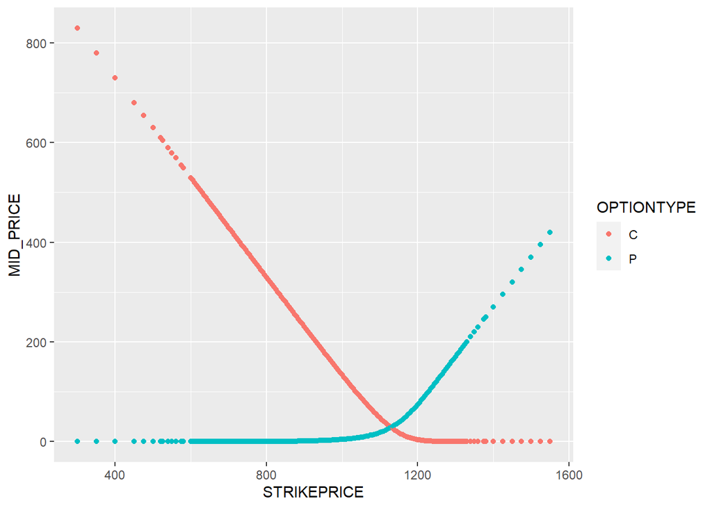

For the open and close of each day, we need to find the relevant option prices for the calculation of the volatility index. First, a specific date must be fixed, then for each expiry date the variance swap is calculated. The fixed 30 day, which is what will be directly compared to the VIX closing price, relies on both near and next term options. Since there are only monthly options in our data set, this means the closest and next closest expiry dates, respectively. The first step in identifying the options to use is to calculate the forward.

## Step 1: Setting Up the Variables

The strike at which we switch from calls to puts.

```r
sp_wide <- dcast(sp500, Time + MATURITYDATE + STRIKEPRICE ~ OPTIONTYPE, value.var = "MID_PRICE")

sp_wide[, diff := abs(C - P)]
sp_wide[, k_min := .SD[which.min(diff), "STRIKEPRICE"], by = .(Time, MATURITYDATE)]
sp_wide <- sp_wide[k_min == STRIKEPRICE, .(Time, MATURITYDATE, k_min, diff)]

sp500 <- merge(sp500, sp_wide,
               by = c("Time", "MATURITYDATE")
               )

sp500 <- sp500 %>%
  mutate(
    forward = k_min + exp(in_interest_rate * years_to_expiry) * diff
  )
```

The forward should lie very near to where the put and call lines crossed in test 1, and to verify this the test will be run again with the forward set as the x intercept.

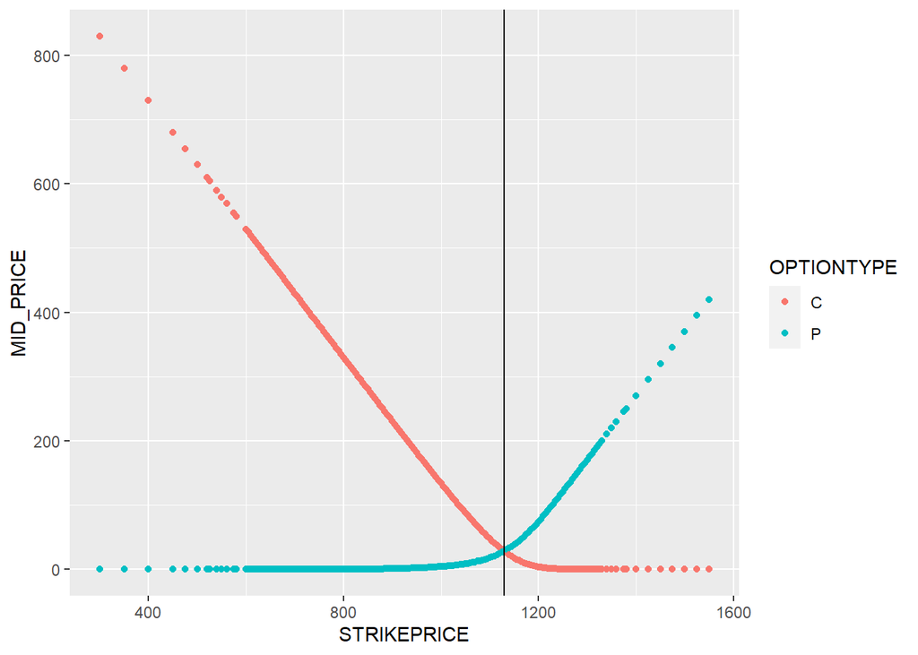

The next step is to find the k_zero value, the closest strike below the forward level

```r
sp500[, diff := forward - STRIKEPRICE]
sp500[diff < 0, diff := NA]

sp500[, k_zero := .SD[which.min(diff), "STRIKEPRICE"], by = .(Time, MATURITYDATE)]
```

Running the same test as before with k_zero set as the x intercept

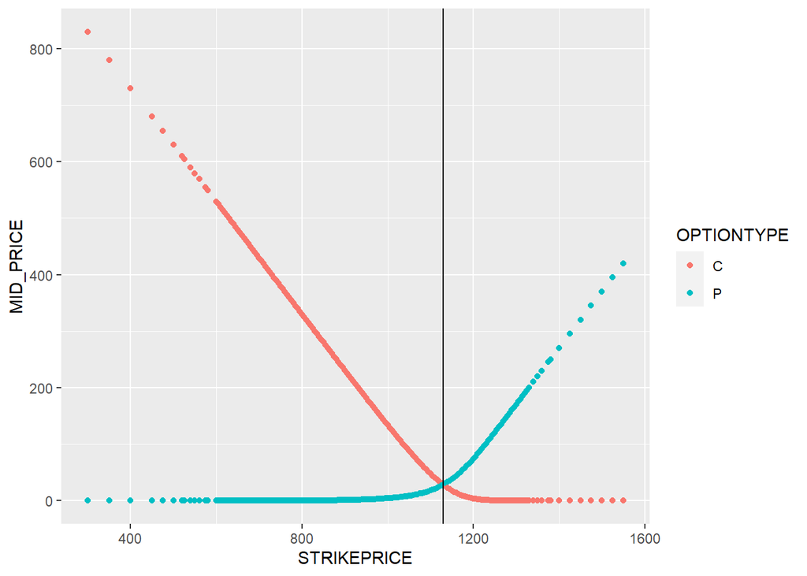

Next, the VIX model calls for the filtering out of options based on certain criteria:  
1. In the money options should be removed  
2. Options with double zero bids, or those preceded by double zero bids should be removed

```r
# Filtering out in the money options
sp500 <- sp500[(OPTIONTYPE == "C" & STRIKEPRICE >= k_zero) | (OPTIONTYPE == "P" & STRIKEPRICE <= k_zero)]

# ID double zero bids
sp500[order(Time, MATURITYDATE, STRIKEPRICE, OPTIONTYPE), last_BID_PRICE := shift(BID_PRICE), by = .(Time, MATURITYDATE, OPTIONTYPE)]
sp500[, is_double_zero_bid := last_BID_PRICE == BID_PRICE & BID_PRICE <= 10^(-31)]
```

Testing now with the new changes applied

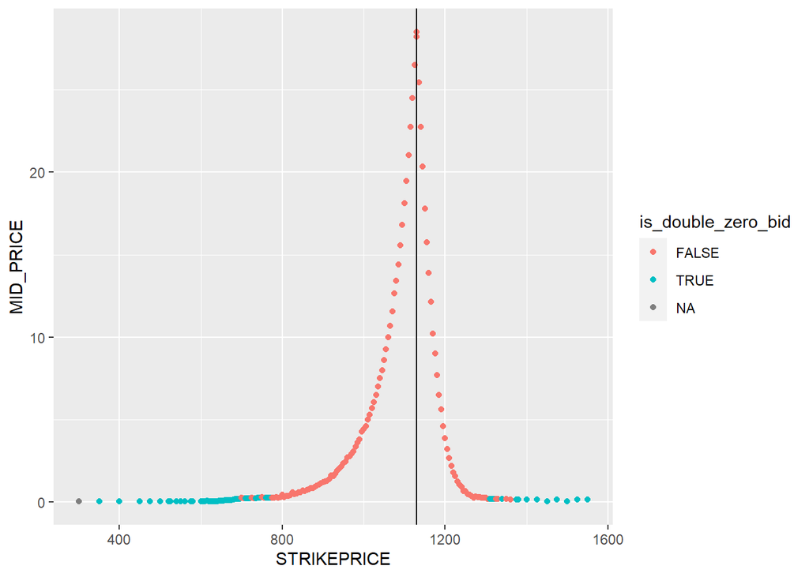

```r
sp500 <- filter(sp500, is_double_zero_bid == FALSE)

sp500[order(Time, MATURITYDATE, STRIKEPRICE, OPTIONTYPE, decreasing = FALSE), last_STRIKEPRICE := shift(STRIKEPRICE), by = .(Time, MATURITYDATE, OPTIONTYPE)]
sp500[order(Time, MATURITYDATE, STRIKEPRICE, OPTIONTYPE, decreasing = TRUE), next_STRIKEPRICE := shift(STRIKEPRICE), by = .(Time, MATURITYDATE, OPTIONTYPE)]
sp500 <- sp500 %>%
  mutate(
    k_delta = (next_STRIKEPRICE - last_STRIKEPRICE) / 2
  )
```

Before moving on to the next step, we’re going to clean out some of the columns in SP500 that no longer need to be there.

```r
sp500 <- sp500[, -c(3,5:8,20:23)]
```

## Step 2: The VIX Summation

Now we have to calculate the volatility for near and next term options from the same starting point. We’ll do near term first, which just needs to be less than a 30 day time to maturity. For this, we’ll need to find a start date that has options expiring in both less than and more than 30 days. The first date of the year to meet this criteria is Jan 22, and it’s been filtered below.

```r
sp500_near <- filter(sp500, Time == "2010-01-22" & days_to_expiry == 29)
```

```r
sp500_next <- filter(sp500, Time == "2010-01-22" & days_to_expiry == 57)
```

From here, we need to calculate the first term of the VIX formula. This makes use of several columns in the data tables:  
years_to_expiry, k_delta, STRIKEPRICE, and MID_PRICE.  
It also makes use of the risk free rate, which has been assumed to be 0 for the purpose of this assignment.

```r
sp500_near <- sp500_near %>%
  mutate(
    contribution = (k_delta / STRIKEPRICE**2) * exp(in_interest_rate*years_to_expiry) * MID_PRICE
  )
sum1 <- sum(sp500_near$contribution, na.rm = TRUE)
T1 <- sp500_near[1,9]
sig_1_left <- sum1*(2/T1)

sig_1_left
```

```
##    years_to_expiry
## 1:       0.0708938
```

```r
sp500_next <- sp500_next %>%
  mutate(
    contribution = (k_delta / STRIKEPRICE**2) * exp(in_interest_rate*years_to_expiry) * MID_PRICE
  )
sum2 <- sum(sp500_next$contribution, na.rm = TRUE)
T2 <- sp500_next[1,9]
sig_2_left <- sum2*(2/T2)

sig_2_left
```

```
##    years_to_expiry
## 1:      0.06937319
```

Up next is the second term in the VIX equation, which makes use of the k_zero, year_to_expiry, and the forward. This will be subtracted from the left terms determined above.

```r
F1 <- sp500_near[1,13]
F2 <- sp500_next[1,13]
k_zero <- sp500_near[1,14]

sig_1_right <- 1/T1 * ((F1/k_zero) - 1)**2
sig_2_right <- 1/T2 * ((F2/k_zero) - 1)**2
```

And now the full sigma^2 for both near term and next term can be calculated as:

```r
sig_1 <- sig_1_left - sig_1_right
sig_1
```

```
##    years_to_expiry
## 1:      0.07089356
```

```r
sig_2 <- sig_2_left - sig_2_right
sig_2
```

```
##    years_to_expiry
## 1:      0.06935475
```

## Step 3: Calculate the 30 day weighted average of the sigma^2 values

This is the home stretch for the 30 day model. All that’s needed now are the sigma values, the time to maturity, and the number of minutes to the option settlements, as well as the number of minutes in a 30 day and 365 day stretch.

```r
N30 <- 43200
N365 <- 525600
Nt1 <- T1*N365
Nt2 <- T2*N365

VIX_left <- T1*sig_1 * ((Nt2-N30) / (Nt2-Nt1))
VIX_right <- T2*sig_2 * ((N30-Nt1) / (Nt2-Nt1))

VIX <- 100*sqrt((N365/N30)*(VIX_left+VIX_right))
VIX
```

```
##    years_to_expiry
## 1:        26.60623
```

## Compare to VIX actual

To compare the above calculations to the actual, we need to use tidyquant to pull the closing data for VIX

```r
vix_actual <- tq_get("^VIX", get = "stock.prices",
                     from = "2010-01-04",
                     to = "2010-12-31")
# Remove some unneeded columns
vix_actual <- vix_actual[, -c(1,3:5,7,8)]
```

To verify that the calculation is accurate, it should be compared to the actual VIX close on 2010-01-22

```r
actual_row <- which(vix_actual == "2010-01-22", arr.ind = TRUE)
vix_actual[actual_row[1,1],2]
```

```
## # A tibble: 1 × 1
##   close
##   <dbl>
## 1  27.3
```

```r
VIX
```

```
##    years_to_expiry
## 1:        26.60623
```

## Set up a loop to calculate the VIX for the rest of the year

```r
dates <- c("2010-01-22","2010-02-22","2010-03-22","2010-04-23","2010-05-21","2010-06-18","2010-07-23","2010-08-23","2010-09-23","2010-10-22","2010-11-22","2010-12-10")
near <- c(29,26,26,29,29,29,29,26,23,29,26,21)
next_ <- c(57,37,61,57,40,64,57,38,58,57,39,43)
vix_results <- data.frame(matrix(ncol = 2, nrow = 12))
colnames(vix_results) <- c('date', 'close2')

i <- 1

while(i < 13){
  sp500_near <- filter(sp500, Time == dates[i] & days_to_expiry == near[i])
  sp500_next <- filter(sp500, Time == dates[i] & days_to_expiry == next_[i])

  sp500_near <- sp500_near %>%
  mutate(
    contribution = (k_delta / STRIKEPRICE**2) * exp(in_interest_rate*years_to_expiry) * MID_PRICE
  )
sum1 <- sum(sp500_near$contribution, na.rm = TRUE)
T1 <- sp500_near[1,9]
sig_1_left <- sum1*(2/T1)

sp500_next <- sp500_next %>%
  mutate(
    contribution = (k_delta / STRIKEPRICE**2) * exp(in_interest_rate*years_to_expiry) * MID_PRICE
  )
sum2 <- sum(sp500_next$contribution, na.rm = TRUE)
T2 <- sp500_next[1,9]
sig_2_left <- sum2*(2/T2)

F1 <- sp500_near[1,13]
F2 <- sp500_next[1,13]
k_zero <- sp500_near[1,14]

sig_1_right <- 1/T1 * ((F1/k_zero) - 1)**2
sig_2_right <- 1/T2 * ((F2/k_zero) - 1)**2

sig_1 <- sig_1_left - sig_1_right
sig_2 <- sig_2_left - sig_2_right

Nt1 <- T1*N365
Nt2 <- T2*N365

VIX_left <- T1*sig_1 * ((Nt2-N30) / (Nt2-Nt1))
VIX_right <- T2*sig_2 * ((N30-Nt1) / (Nt2-Nt1))

VIX <- 100*sqrt((N365/N30)*(VIX_left+VIX_right))

vix_results[i,1] <- dates[i]
vix_results[i,2] <- VIX

i <- i + 1
}

vix_results
```

```
##          date   close2
## 1  2010-01-22 26.60623
## 2  2010-02-22 17.27413
## 3  2010-03-22 15.97162
## 4  2010-04-23 15.57744
## 5  2010-05-21 38.63278
## 6  2010-06-18 22.65600
## 7  2010-07-23 22.50206
## 8  2010-08-23 23.13324
## 9  2010-09-23 22.83754
## 10 2010-10-22 17.79170
## 11 2010-11-22 17.18596
## 12 2010-12-10 16.24335
```

## Compare calculated volatility vs actual over the year

Now that we have a matrix of dates and closing VIX values we can graphically compare them to the actuals that were pulled earlier.

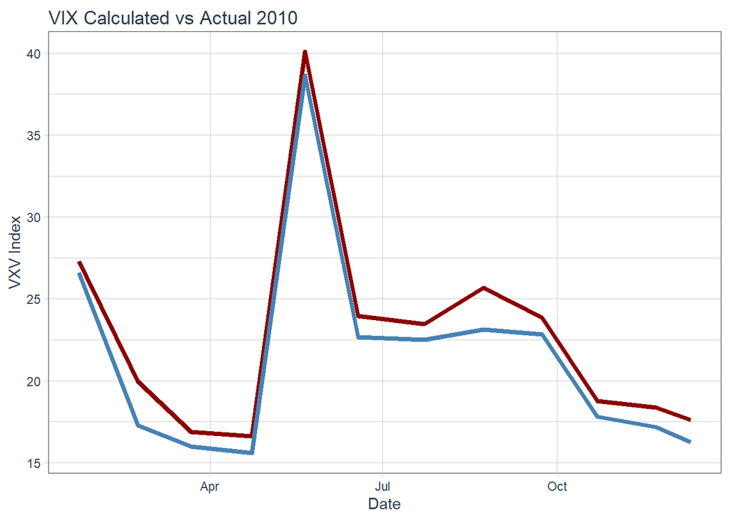

```r
vix_compare <- merge(vix_actual, vix_results, by = "date")
vix_compare %>%
  ggplot(aes(x = "date"))+
  geom_line(aes(x= date, y = close), color = "darkred", size = 1.5)+
  geom_line(aes(x=date, y = close2), color = "steelblue", size = 1.5)+
  labs(x = "Date", y = "VXV Index",
       title = "VIX Calculated vs Actual 2010")+
  theme_tq()
```

From this we can see that our calculations consistently hover just under the actuals. The reason for this difference is likely the fact that the actual index has access to weekly option data as well, which would increase the volatility by a non constant amount for any given period. This lack of weekly data is also the reason why we can’t make calculations for every day the way the real model can.  
To measure the accuracy of our model, we need to know how well it correlates with the actual data.

```r
vix_cor <- cor(vix_compare$close, vix_compare$close2, method = "pearson",)
vix_cor
```

```
## [1] 0.9955111
```

With a correlation of over 99% we can conclude that our model is very accurate.

## 93 Day VXV Model

Now that the 30 day model has been computed and verified, we must do the same for the 93 day volatility index. The variables that we prepared for the model are still valid, the only thing that changes here is the dates we select, and the options we select. This time the near term must be any option that will reach maturity in under 93 days, and the next term will be the next set due just like last time. They will again be manually selected to ensure that any data put through the model is valid.

```r
N93 <- 133920

sp500_test <- filter(sp500, Time == "2010-12-10")

dates <- c("2010-01-22","2010-02-22","2010-03-22","2010-04-23","2010-05-21","2010-06-18","2010-07-23","2010-08-23","2010-09-23","2010-10-22","2010-11-22","2010-12-10")
near <- c(85,89,89,85,92,92,85,89,86,92,89,71)
next_ <- c(120,117,100,120,120,104,120,117,99,120,117,99)
vxv_results <- data.frame(matrix(ncol = 2, nrow = 12))
colnames(vxv_results) <- c('date', 'close2')

i <- 1

while(i < 13){
  sp500_near <- filter(sp500, Time == dates[i] & days_to_expiry == near[i])
  sp500_next <- filter(sp500, Time == dates[i] & days_to_expiry == next_[i])

sp500_near <- sp500_near %>%
  mutate(
    contribution = (k_delta / STRIKEPRICE**2) * exp(in_interest_rate*years_to_expiry) * MID_PRICE
  )
sum1 <- sum(sp500_near$contribution, na.rm = TRUE)
T1 <- sp500_near[1,9]
sig_1_left <- sum1*(2/T1)

sp500_next <- sp500_next %>%
  mutate(
    contribution = (k_delta / STRIKEPRICE**2) * exp(in_interest_rate*years_to_expiry) * MID_PRICE
  )
sum2 <- sum(sp500_next$contribution, na.rm = TRUE)
T2 <- sp500_next[1,9]
sig_2_left <- sum2*(2/T2)

F1 <- sp500_near[1,13]
F2 <- sp500_next[1,13]
k_zero <- sp500_near[1,14]

sig_1_right <- 1/T1 * ((F1/k_zero) - 1)**2
sig_2_right <- 1/T2 * ((F2/k_zero) - 1)**2

sig_1 <- sig_1_left - sig_1_right
sig_2 <- sig_2_left - sig_2_right

Nt1 <- T1*N365
Nt2 <- T2*N365

VXV_left <- T1*sig_1 * ((Nt2-N93) / (Nt2-Nt1))
VXV_right <- T2*sig_2 * ((N93-Nt1) / (Nt2-Nt1))

VXV <- 100*sqrt((N365/N93)*(VXV_left+VXV_right))

vxv_results[i,1] <- dates[i]
vxv_results[i,2] <- VXV

i <- i + 1
}

vxv_results
```

```
##          date   close2
## 1  2010-01-22 25.27990
## 2  2010-02-22 20.81023
## 3  2010-03-22 18.79135
## 4  2010-04-23 18.57071
## 5  2010-05-21 36.76801
## 6  2010-06-18 26.91694
## 7  2010-07-23 25.85310
## 8  2010-08-23 28.19387
## 9  2010-09-23 25.11836
## 10 2010-10-22 20.78246
## 11 2010-11-22 20.40118
## 12 2010-12-10 19.38919
```

Since the 93 day index is not available on yahoo finance it will need to be pulled from FRED using a slightly different function than the vix actuals

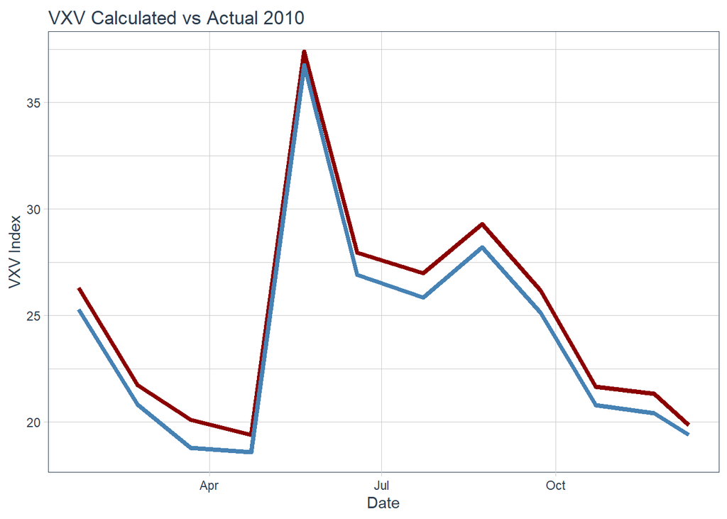

```r
vxv_actual <- tq_get("VXVCLS", get = "economic.data",
                     from = "2010-01-04",
                     to = "2010-12-31" )
vxv_actual <- vxv_actual[, -1]

vxv_compare <- merge(vxv_actual, vxv_results, by = "date")
vxv_compare %>%
  ggplot(aes(x = "date"))+
  geom_line(aes(x= date, y = price), color = "darkred", size = 1.5)+
  geom_line(aes(x=date, y = close2), color = "steelblue", size = 1.5)+
  labs(x = "Date", y = "VXV Index",
       title = "VXV Calculated vs Actual 2010")+
  theme_tq()
```

```r
vxv_cor <- cor(vxv_compare$price, vix_compare$close2, method = "pearson")
vxv_cor
```

```
## [1] 0.9570111
```